```python
import os
# graphviz 패키지 에러로 인한 path 설정
os.environ["PATH"]+=os.pathsep+'C:/Program Files (x86)/Graphviz/bin/'
```

# Decision Tree [의사결정나무]

# 1.의사결정나무란 어떤 모델인가

- 의사결정나무는 데이터를 분석하여 이들 사이에 존재하는 패턴을 예측 가능한 규칙들의 조합으로 나타내는 것을 말한다.

**적은 질문으로 문제를 해결하는 것**

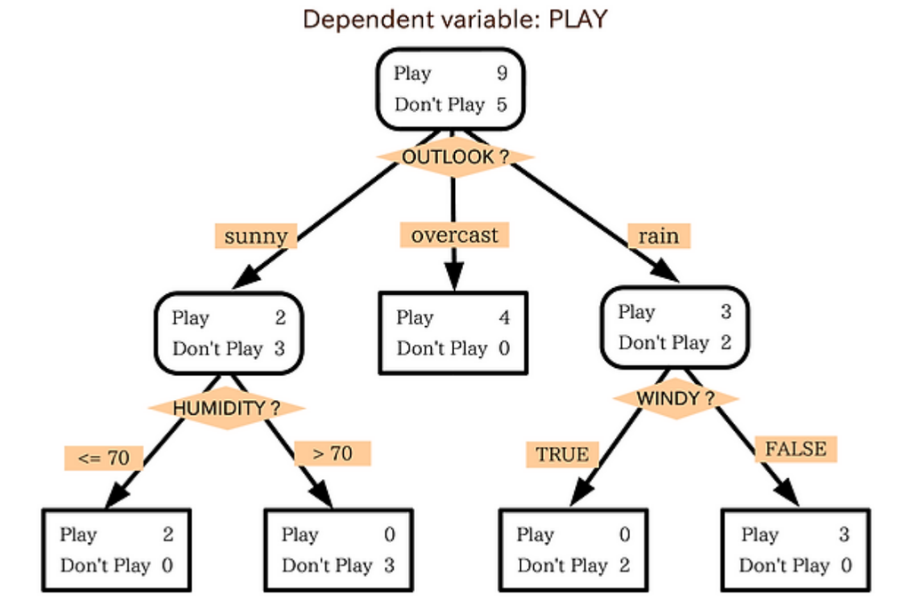

- 이진분류 사례: 운동경기가 열렸다면 Play = 1, 열리지 않았다면 Play = 0
- 그림 해석: 날씨가 맑고 습도가 70 이하인 날에는 경기가 2번 열렸다.

# 2. 의사결정나무의 구조

### 의사결정나무를 구성하는 node

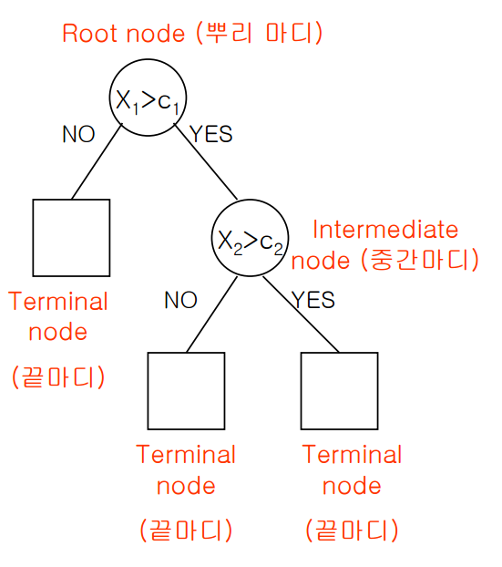

- Root node: **시작 지점**으로 분기가 거듭될 수록 해당하는 노드가 줄어든다.
- Terminal node / Leaf node: **결정된 클래스 값** 터미널 노드 내의 데이터 개수를 합하면 루트의 데이터 수와 일치한다. 터미널 노드 간에는 교집합이 존재하지 않으며, 터미널 노드의 갯수가 분리된 루트노드 집합의 개수이다.
- Decision Node / Internal Node: 데이터세트의 피처가 결합해서 만들어지는 분류를 위한 **규칙조건이 담긴** 노드이다. 각 노드연결간의 중간 노드로 Itermidiate node라고도 한다.

## 3. 의사결정나무의 특징

#### 분류(classification)와 회귀(regression) 모두 가능

- **범주형 변수 [ 분류 ]**

  : 새로운 데이터가 특정 Terminal node에 속한다는 정보를 확인한 뒤 그 터미널 노드에서 가장 빈도가 높은 범주에 새로운 데이터를 분류한다.
- **연속형 변수 [ 회귀 ]**

  : 해당하는 터미널 노드의 종속변수(y)의 평균값을 예측값으로 반환한다. 이때 예측값의 종류는 터미널 노드의 개수와 일치한다. 만약 터미널 노드의 개수가 5개라면 새로운 데이터가 몇개가 주어지더라도 5종류의 답만 출력한다.
- SVM 처럼 분류와 회귀가 모두 가능한 머신러닝 알고리즘이다.
- 매우 복잡한 데이터셋도 학습이 가능하다.
- 랜덤포레스트 모델의 기본 구성 요소이다.

### 의사결정나무의 데이터 분할 방법

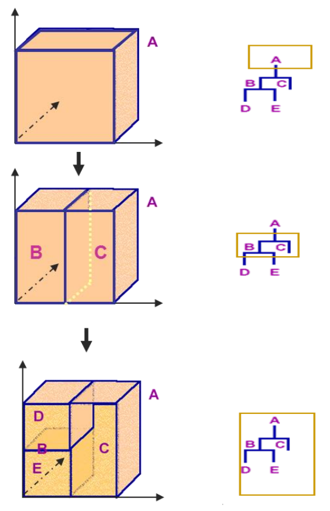

- 예시: 설명변수(X)가 3개인 다변량 데이터에 적용한 의사결정 나무 그림.

  D 특성을 가지고 있는 새로운 데이터가 주어졌을 때 의사결정나무는 D 집합을 대표할 수 있는 값(분류의 경우 최빈값을 회귀의 경우 평균값)을 반환하는 형식으로 예측을 출력한다.

# 4. 불순도와 불확실성

의사결정나무는 분기마나 변수의 영역을 두개로 구분하는 모델이다.

- 그럼 영역을 구분하는 기준은 뭘까?

: 의사결정나무는 데이터를 구분하고 난 뒤 각 영역의 **순도(homogeneity)는 증가**하고 **불순도(impurity)와 불확실성(uncertainty)은 최대한 감소**하도록 하는 방향으로 학습을 진행한다.

이처럼 순도는 증가하고 불확실성이 감소하는 것을 정보이론에서 **정보획득**(information gain)이라고 한다.

### **데이터의 순도를 계산하는 방식 3가지**

- 엔트로피(entropy)(불확실성 지표) : 엔트로피가 감소한다 = 불확실성이 감소한다 = 순도가 증가한다 = 정보를 획득했다.
- 지니계수(gini index)(불순도 지표 = 불평등지표) : 경제학에서 불평등지수를 나타낼 때 사용하는 것으로 0일때 완전 평등, 1일때 완전 불평등을 의미한다. 머신러닝에서는 데이터가 다양한 값을 가질수록 0에 가깝게, 평향된 값을 가질수록 불평등한 값이 된다. (사이킷런 패키지의 경우 지니계수를 기본값으로 데이터를 분할한다.)
- 오분류오차(misclassification error) : 불순도를 측정할 수 있긴 하나 나머지 두 지표와 달리 미분이 불가능하다.

### **Decision Tree의 장단점**

- 장점
  - 쉽고 직관적이다. 알아보기 쉬운 시각화로 비전문가도 이해하기 쉽다,
  - 각 피처의 스케일링 혹은 정규화 과정과 같은 전처리 작업의 영향도가 크지 않다.
- 단점
  - 규칙을 추가해 서브트리를 만들고 모델의 깊이가 깊어질수록 모델이 복잡해지며 과적합되기 쉽다. -트리의 크기를 사전에 제한하는 튜닝 작업이 필요하다 = **가지치기**

### 4 - 1 유방암 데이터 셋을 이용한 가지치기 실습

- Tensorflow 공식블로그 참조

```python
import numpy as np
import pandas as pd
import matplotlib.pyplot as plt
from sklearn.model_selection import train_test_split
from sklearn.tree import DecisionTreeClassifier
from sklearn.datasets import load_breast_cancer

cancer = load_breast_cancer() # 데이터 불러오기
X_train, X_test, y_train, y_test = train_test_split( # 데이터 분할
    cancer.data, cancer.target, stratify=cancer.target, random_state=42)


tree = DecisionTreeClassifier(random_state=0) # 제약 없이 모델 구성
tree.fit(X_train, y_train) # 모델 학습


print("훈련 세트 정확도: {:.3f}".format(tree.score(X_train, y_train)))
print("테스트 세트 정확도: {:.3f}".format(tree.score(X_test, y_test)))
```

```
훈련 세트 정확도: 1.000
테스트 세트 정확도: 0.937
```

**과적합 상태**

- 모든 리프노드가 순수노드로 학습되었으며 훈련 세트의 정확도가 100%라는 이야기. 트리의 구성이 훈련 데이터릐 모든 레이블을 맞출 수 있을 만큼의 깊이로 구성됨.
- 결정 트리의 깊이를 제한하지 않았기 때문에 훈련 세트가 모델에 과적합된 상태로 볼 수 있음.

```python
# pre-pruning 방법으로 과적합 제한.

tree_m4 = DecisionTreeClassifier(max_depth=4, random_state=0) # 최대 깊이 4
tree_m4.fit(X_train, y_train)

print("훈련 세트 정확도: {:.3f}".format(tree_m4.score(X_train, y_train)))
print("테스트 세트 정확도: {:.3f}".format(tree_m4.score(X_test, y_test)))
```

```
훈련 세트 정확도: 0.988
테스트 세트 정확도: 0.951
```

**pre-pruning**

- 결정트리의 최대 깊이를 4로 제한하면 트리는 연속되는 질문을 4이하로 제한함.
- 훈련세트의 정확도는 떨어졌으나 테스트 셋의 정확도는 상승하는걸 확인 할 수 있다.

```python
#!/bin/env python
#-*- coding: utf-8 -*-
import matplotlib.pyplot as plt  #한글 폰트 설정
plt.rcParams['font.family'] = 'Malgun Gothic'

from sklearn.tree import export_graphviz
export_graphviz(tree, out_file="tree.dot", class_names=["malignant", "benign"],
                feature_names=cancer.feature_names,
                impurity=False, filled=True)

#"malignant", "benign" 악성 & 양성

import graphviz

with open("tree.dot") as f:
    dot_graph = f.read()
display(graphviz.Source(dot_graph))
```

[figure not shown]

```python
from sklearn.tree import export_graphviz
export_graphviz(tree_m4, out_file="tree_m4.dot", class_names=["malignant", "benign"],
                feature_names=cancer.feature_names,
                impurity=False, filled=True)

#"malignant", "benign" 악성 & 양성

with open("tree_m4.dot") as f:
    dot_graph = f.read()
display(graphviz.Source(dot_graph))
```

[figure not shown]

## 5. 특성 중요도

결정나무의 결과 표는 한눈에 들어오지 않아 확인이 어려운데 이때 확인하는 방법이 **특성 중요도 표**이다. 특성 중요도는 0과 1사이의 숫자로 0에 가까울 수록 전혀 사용되지 않았다는 뜻이고 1은 완벽하게 타겟 클래스를 예측했다는 뜻이다. 전체 합은 언제나 1이다.

```
특성 중요도:
[0.         0.         0.         0.         0.         0.
 0.         0.         0.         0.         0.01019737 0.04839825
 0.         0.         0.0024156  0.         0.         0.
 0.         0.         0.72682851 0.0458159  0.         0.
 0.0141577  0.         0.018188   0.1221132  0.01188548 0.        ]
```

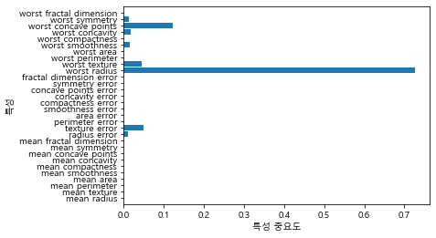

```python
print("특성 중요도:\n{}".format(tree_m4.feature_importances_))

def plot_feature_importances_cancer(model):
    n_features = cancer.data.shape[1]
    plt.barh(range(n_features), model.feature_importances_, align='center')
    plt.yticks(np.arange(n_features), cancer.feature_names)
    plt.xlabel("특성 중요도")
    plt.ylabel("특성")
    plt.ylim(-1, n_features)


plot_feature_importances_cancer(tree_m4)
```

선형 모델의 계수와는 다르게 특성 중요도는 항상 양수로 도출되기 때문에 각 특성들이 **어떤 클래스를 지지** 하는지는 알 수 없다. 위 분류 모델의 경우 worst radius가 중요하다는 것을 알 수 있으나 높은 radius가 유방암 양성을 의미하는지 악성을 의미하는 지는 알 수 없다.

### **POINT & TIP**

**Decision Tree**는 트리의 깊이가 깊어질수록 **과적합되기 쉬워**지고 이는 **예측성능의 저하**로 이어진다. 이를 막기 위해서는 **가지치기**와 같은 방법으로 모델의 크기를 튜닝해야 한다.

결정나무는 사전에 가지치기를 하더라도 과적합되는 일이 비일비재하여 일반화 성능이 좋지 않다.

사이킷런 패키지로 Decision Tree Classifier를 다룰 때 모델을 구성하는 파라미터는 다음과 같다.

> **min_samples_split** : 노드를 분할하기 위한 최소한의 샘플 데이터 수, 과적합 제어에 사용된다. 기본값은 2로 작게 설정할 수 록 분할 노드가 많아져 과적합 가능성이 증가한다.

> **min_samples_leaf** : 리프노드가 되기 위해 필요한 최소한의 샘플 데이터 수, 과적합 제어에 사용된다. 불균형 데이터(지니계수가 1에 가까운 데이터)의 경우 특정 클래스의 데이터가 극도로 작을 수 있으므로 작게 설정하는 것이 좋다.

> **max_features** : 최적의 분할을 위해 고려할 최대 피처 개수, 기본값은 Nonde으로 데이터 세트의 모든 피처를 사용한다.(int로 지정시 피처 갯수 / float으로 지정시 비중 / sqrt or auto로 지정시 전체 피처 중 root(피처 개수)만큼 선정 / log로 지정시 전체 피처 중 log2(전체 피처 개수) 만큼 선정)

> **max_depth** : 트리의 최대 깊이, 기본값은 None으로 완벽하게 클래스 값이 결정될 때 까지 분할 하거나 데이터 개수가 min_samples_split보다 작아질 때 까지 분할한다. 깊이가 깊어지면 과적합될 수 있으므로 적절히 제어할 필요가 있다.

> **max_leaf_nodes** : 리프노드의 최대 개수이다.

### 5 - 1 Iris data set을 이용한 Decision Tree모델 구성 실습

위에서 설명한 파라미터를 이용해 decision tree 모델을 간결화 한다.

```python
from sklearn.datasets import load_iris
import warnings
warnings.filterwarnings('ignore')

iris_data = load_iris() # 데이터 불러오기
X_train, X_test, y_train, y_test = train_test_split( # 데이터 분할
    iris_data.data, iris_data.target, test_size=0.2, random_state=11)

tree_iris = DecisionTreeClassifier(random_state=156) # 모델 구성
tree_iris.fit(X_train, y_train) # 모델 학습
```

```
DecisionTreeClassifier(random_state=156)
```

```python
### 기본 모델
export_graphviz(tree_iris, out_file="tree_iris.dot", class_names = iris_data.target_names,
                           feature_names = iris_data.feature_names, impurity=True, filled=True)

print('----- decision tree 시각화 자료 읽기  ------')
print(' ')
print('petal length (cm) <= 2.45: 자식 노드를 만들기 위한 규칙 조건, 조건이 없는 경우 리프노드')
print('gini: value = []로 주어진 데이터 분포에서의 지니계수')
print('sample: 현 규칙에 해당하는 데이터의 갯수')
print('value: [] 클래스 값에 기반하는 데이터의 개수(ex. 0:setosa, 1: versicolor, 2:virginia)')
print(' ')
print('===== 아무 제약이 없는 경우 =====')

with open("tree_iris.dot") as f:
    dot_graph = f.read()
graphviz.Source(dot_graph)
```

```
----- decision tree 시각화 자료 읽기  ------

petal length (cm) <= 2.45: 자식 노드를 만들기 위한 규칙 조건, 조건이 없는 경우 리프노드
gini: value = []로 주어진 데이터 분포에서의 지니계수
sample: 현 규칙에 해당하는 데이터의 갯수
value: [] 클래스 값에 기반하는 데이터의 개수(ex. 0:setosa, 1: versicolor, 2:virginia)

===== 아무 제약이 없는 경우 =====
```

[figure not shown]

```python
### (min_samples_split=4
dt_clf = DecisionTreeClassifier(min_samples_split=4 ,random_state=156)
dt_clf.fit(X_train, y_train)

export_graphviz(dt_clf, out_file="tree.dot", class_names = iris_data.target_names,
                           feature_names = iris_data.feature_names, impurity=True, filled=True)

print('===== min_samples_split=4인 경우의 Decision Tree 시각화 =====')
print(' ')
print('sample 최소 갯수가 3인 경우 샘플 내에 다른 값이 있어도 더이상 분할하지 않는다.')


with open("tree.dot") as f:
    dot_graph = f.read()
graphviz.Source(dot_graph)
```

```
===== min_samples_split=4인 경우의 Decision Tree 시각화 =====

sample 최소 갯수가 3인 경우 샘플 내에 다른 값이 있어도 더이상 분할하지 않는다.
```

[figure not shown]

```python
dt_clf = DecisionTreeClassifier(min_samples_leaf=4 ,random_state=156)
dt_clf.fit(X_train, y_train)


export_graphviz(dt_clf, out_file="tree.dot", class_names = iris_data.target_names,
                           feature_names = iris_data.feature_names, impurity=True, filled=True)

print('===== min_samples_leaf=4인 경우의 Decision Tree 시각화 =====')
print(' ')
print('리프노드가 될 수 있는 샘플 데이터의 최소 갯수를 지정한다. 자식이 없는 리프노드는 클래스 값이 결정된다. ')

with open("tree.dot") as f:
    dot_graph = f.read()
graphviz.Source(dot_graph)
```

```
===== min_samples_leaf=4인 경우의 Decision Tree 시각화 =====

리프노드가 될 수 있는 샘플 데이터의 최소 갯수를 지정한다. 자식이 없는 리프노드는 클래스 값이 결정된다.
```

[figure not shown]

# 6. Decision Tree의 과적합 문제

임의의 데이터 세트를 이용한 과적합 문제 시각화

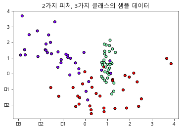

```python
from sklearn.datasets import make_classification
import matplotlib.pyplot as plt

plt.title("2가지 피처, 3가지 클래스의 샘플 데이터")

# 2차원 시각화를 위해 피처는 2개, 클래스 3개로 분류되는 샘플데이터 생성
X_features, y_labels = make_classification(n_features=2, n_redundant=0, n_informative=2,
                                                                  n_classes=3, n_clusters_per_class=1, random_state=0)

# 그래프 형태로 2개의 피쳐로 2차원 좌표 시각화, 각 클래스는 다른 색으로 표시한다.
plt.scatter(X_features[:, 0], X_features[:, 1], marker='o', c=y_labels, s=25, edgecolor = 'k', cmap='rainbow')
```

- 트리를 생성하는 파라미터를 모두 기본값으로 놓고, 데이터가 어떻게 분류되는지 확인 한다.

```python
# Classifier의 Decision Boundary를 시각화 하는 함수
def visualize_boundary(model, X, y):
    fig,ax = plt.subplots()

    # 학습 데이타 scatter plot으로 나타내기
    ax.scatter(X[:, 0], X[:, 1], c=y, s=25, cmap='rainbow', edgecolor='k',
               clim=(y.min(), y.max()), zorder=3)
    ax.axis('tight')
    ax.axis('off')
    xlim_start , xlim_end = ax.get_xlim()
    ylim_start , ylim_end = ax.get_ylim()

    # 호출 파라미터로 들어온 training 데이타로 model 학습 .
    model.fit(X, y)
    # meshgrid 형태인 모든 좌표값으로 예측 수행.
    xx, yy = np.meshgrid(np.linspace(xlim_start,xlim_end, num=200),np.linspace(ylim_start,ylim_end, num=200))
    Z = model.predict(np.c_[xx.ravel(), yy.ravel()]).reshape(xx.shape)

    # contourf() 를 이용하여 class boundary 를 visualization 수행.
    n_classes = len(np.unique(y))
    contours = ax.contourf(xx, yy, Z, alpha=0.3,
                           levels=np.arange(n_classes + 1) - 0.5,
                           cmap='rainbow', clim=(y.min(), y.max()),
                           zorder=1)

# 출처 : https://injo.tistory.com/15
```

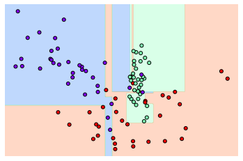

```python
# 파라미터를 따로 설정하지 않은 Decision Tree의 학습 & 결정 경계 시각화
dt_clf = DecisionTreeClassifier().fit(X_features, y_labels)
visualize_boundary(dt_clf, X_features, y_labels)
```

**해석**

```
매우 얇은 영역에 존재하는 데이터(이상치)도 분류하기 위해 결정 경계가 많아짐.

> 조금이라도 다른 형태의 데이터가 들어오는 경우 정확도가 수직 하락
```

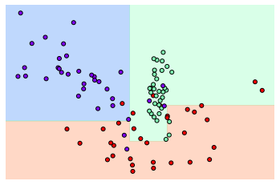

```python
# min_samples_leaf = 6 으로 설정한 Decision Tree의 학습 & 결정 경계 시각화
dt_clf = DecisionTreeClassifier(min_samples_leaf=6).fit(X_features, y_labels)
visualize_boundary(dt_clf, X_features, y_labels)
```

**해석**

```
이상치에 둔감하게 반응하며 일반화된 분류 규칙에 의해 새롭게 데이터가 분류됨.
```

#### Decision Tree의 과적합을 줄이기 위한 파라미터 튜닝방법 정리

[output not shown]